# Step 1: Prepare inputs for replicate-matched monkey study-design simulations

Author

NAMLink

# Purpose and review gate

This first script prepares the complete, reproducible input record for the reanalysis. The reviewed full-scale configuration creates 50 virtual monkeys and 100 replicate-level parameter draws at each variability level without changing the approved analysis rules.

One five-parameter draw is one Monte Carlo replicate. Within a replicate, the five values remain fixed across all monkeys and doses. Body weight and target reference concentration vary between monkeys.

This script does **not** run concentration-time simulations. Review the rendered report and saved input artifacts before proceeding to Step 2. Diagnostic tables remain in the HTML report. The only separate Step 1 files are the consolidated R object plus the parameter-draw, body-weight population, and target-population tables required downstream.

```r
rm(list = ls())

suppressPackageStartupMessages({
  library(dplyr)
  library(esqlabsR)
  library(ggplot2)
  library(knitr)
  library(ospsuite)
  library(purrr)
  library(readr)
  library(scales)
  library(tibble)
  library(tidyr)
})

find_project_root <- function(start = getwd()) {
  current <- normalizePath(start, winslash = "/", mustWork = TRUE)
  repeat {
    required <- c(
      file.path(current, "00_Data"),
      file.path(current, "01_Models"),
      file.path(current, "02_APriori_PBPK_Workflow"),
      file.path(current, "03_Study_Simulations")
    )
    if (all(dir.exists(required))) return(current)
    parent <- dirname(current)
    if (identical(parent, current)) {
      stop("Could not locate the PBPK_mAb_NAM_Tutorial project root.")
    }
    current <- parent
  }
}

assert_files_exist <- function(paths, description = "Required input") {
  missing <- paths[!file.exists(paths)]
  if (length(missing) > 0L) {
    stop(description, " is missing: ", paste(missing, collapse = "; "))
  }
  invisible(paths)
}

draw_lognormal_mean_cv <- function(n, arithmetic_mean, cv) {
  if (!is.finite(arithmetic_mean) || arithmetic_mean <= 0) {
    stop("A lognormal arithmetic mean must be positive and finite.")
  }
  if (!is.finite(cv) || cv < 0) {
    stop("CV must be non-negative and finite.")
  }
  sdlog <- sqrt(log1p(cv^2))
  meanlog <- log(arithmetic_mean) - 0.5 * sdlog^2
  rlnorm(n, meanlog = meanlog, sdlog = sdlog)
}

PROJECT_ROOT <- find_project_root()
APRIORI_DIR <- file.path(PROJECT_ROOT, "02_APriori_PBPK_Workflow")
STUDY_DIR <- file.path(PROJECT_ROOT, "03_Study_Simulations")
OUTPUT_DIR <- file.path(STUDY_DIR, "SimsOutputs", "Step1_Inputs")
TABLE_DIR <- file.path(OUTPUT_DIR, "Tables")
OBJECT_DIR <- file.path(OUTPUT_DIR, "Objects")

walk(
  c(OUTPUT_DIR, TABLE_DIR, OBJECT_DIR),
  dir.create,
  recursive = TRUE,
  showWarnings = FALSE
)

MOLECULES <- c("Golimumab", "Nivolumab")
SOURCE_SCENARIOS <- c(
  Golimumab = "Golimumab_Monkey_3_mpk",
  Nivolumab = "Nivolumab_Monkey_1_mpk"
)
SOURCE_DOSES_MG_KG <- c(Golimumab = 3, Nivolumab = 1)
MODEL_FILES <- c(
  Golimumab = "PKML_Files_Monkey/PKML_Files_Monkey/AntiTNFA.pkml",
  Nivolumab = "PKML_Files_Monkey/PKML_Files_Monkey/AntiPD1.pkml"
)
TRUTH_MODEL_ROLES <- c(
  Golimumab = "Nominal uncalibrated Golimumab truth",
  Nivolumab = "Calibrated Nivolumab truth"
)

DOSES_MG_KG <- c(0.1, 1, 3, 10, 30)
VARIABILITY_CV <- c(0.30, 0.60)

# Full scale after review of the 10-replicate, 10-monkey pilot.
N_REPLICATES <- 100L
N_POPULATION_ANIMALS <- 50L
N_REPLICATES_PER_BATCH <- 10L
POPULATION_NAME <- "Monkey"
POPULATION_SEED <- 20260919L
PARAMETER_DRAW_SEED_BASE <- 20260919L
TARGET_POPULATION_SEED_BASE <- 20261919L

ANIMALS_PER_GROUP <- c(2L, 3L, 6L)
DESIGN_DOSES <- list(
  `2 dose groups` = c(1, 10),
  `3 dose groups` = c(0.1, 1, 10),
  `5 dose groups` = c(0.1, 1, 3, 10, 30)
)

AUC_END_H <- 28 * 24
DENSE_TIME_H <- sort(unique(c(
  seq(0.25, 8, by = 0.25),
  seq(9, AUC_END_H, by = 1)
)))
SPARSE_TIME_H <- sort(unique(c(
  0.25, 1, 2, 4, 8,
  1, 2, 6, 10, 14, 21, 28
) * c(rep(1, 5), rep(24, 7))))

MAB_PLASMA_OUTPUT_PATH <-
  "Organism|PeripheralVenousBlood|mAb|Plasma (Peripheral Venous Blood)"
DOSE_PATH <-
  "Events|IV_Bolus|Application_1|ProtocolSchemaItem|DosePerBodyWeight"
PARAMETER_PATHS <- c(
  `Kd (FcRn)` = "mAb|Kd (FcRn) in endosomal space",
  `Target Kd` = "mAb-Target-InVitro|Kd",
  koff = "mAb-Target-InVitro|koff",
  kint = "Complex Internalization|kint",
  kdeg = "Target degradation|kdeg"
)
TARGET_REFERENCE_PATH <- "Target|Reference concentration"
WEIGHT_PATH <- "Organism|Weight"
MODEL_INPUT_PATHS <- c(
  PARAMETER_PATHS,
  `Target reference concentration` = TARGET_REFERENCE_PATH
)

NIVOLUMAB_FCRN_KD_UMOL_L <- 0.39

PROJECT_CONFIG_FILE <- file.path(APRIORI_DIR, "ProjectConfiguration.xlsx")
POPULATION_CONFIG_FILE <- file.path(
  APRIORI_DIR, "Configurations", "Populations.xlsx"
)
MONKEY_DATA_FILE <- file.path(
  PROJECT_ROOT, "00_Data", "Monkey", "mAb_data.csv"
)
CALIBRATED_NIVOLUMAB_PROJECT_FILE <- file.path(
  PROJECT_ROOT,
  "01_Models", "PK-Sim_Mobi_Files_Monkey",
  "AntiPD1_Nivo_Calibrated.mbp3"
)
MODEL_PATHS <- file.path(PROJECT_ROOT, "01_Models", unname(MODEL_FILES))

STEP1_RDS <- file.path(
  OBJECT_DIR,
  "study_design_step1_inputs.rds"
)
BASE_POPULATION_FILE <- file.path(
  TABLE_DIR,
  "study_design_base_monkey_population.csv"
)
MODEL_MANIFEST_FILE <- file.path(
  TABLE_DIR,
  "study_design_model_manifest.csv"
)
PARAMETER_CENTER_FILE <- file.path(
  TABLE_DIR,
  "study_design_parameter_centers.csv"
)
PARAMETER_DRAW_FILE <- file.path(
  TABLE_DIR,
  "study_design_parameter_draws.csv"
)
PARAMETER_DRAW_DIAGNOSTIC_FILE <- file.path(
  TABLE_DIR,
  "study_design_parameter_draw_diagnostics.csv"
)
TARGET_POPULATION_FILE <- file.path(
  TABLE_DIR,
  "study_design_target_population.csv"
)
TARGET_POPULATION_DIAGNOSTIC_FILE <- file.path(
  TABLE_DIR,
  "study_design_target_population_diagnostics.csv"
)
CROSSED_PROFILE_INDEX_FILE <- file.path(
  TABLE_DIR,
  "study_design_crossed_profile_index.csv"
)
DESIGN_MANIFEST_FILE <- file.path(
  TABLE_DIR,
  "study_design_candidate_designs.csv"
)
TIME_MANIFEST_FILE <- file.path(
  TABLE_DIR,
  "study_design_time_grids.csv"
)
SIMULATION_MANIFEST_FILE <- file.path(
  TABLE_DIR,
  "study_design_simulation_manifest.csv"
)
BATCH_MANIFEST_FILE <- file.path(
  TABLE_DIR,
  "study_design_batch_manifest.csv"
)
SETTINGS_FILE <- file.path(
  TABLE_DIR,
  "study_design_step1_settings.csv"
)
PACKAGE_FILE <- file.path(
  TABLE_DIR,
  "study_design_software_versions.csv"
)
ARTIFACT_MANIFEST_FILE <- file.path(
  TABLE_DIR,
  "study_design_step1_artifact_manifest.csv"
)

assert_files_exist(
  c(
    PROJECT_CONFIG_FILE,
    POPULATION_CONFIG_FILE,
    MONKEY_DATA_FILE,
    CALIBRATED_NIVOLUMAB_PROJECT_FILE,
    MODEL_PATHS
  ),
  "Step 1 input"
)

package_record <- tibble(
  Package = c(
    "R", "dplyr", "esqlabsR", "ggplot2", "knitr",
    "ospsuite", "purrr", "readr", "tibble", "tidyr"
  ),
  Version = c(
    paste(R.version$major, R.version$minor, sep = "."),
    map_chr(
      c(
        "dplyr", "esqlabsR", "ggplot2", "knitr", "ospsuite",
        "purrr", "readr", "tibble", "tidyr"
      ),
      ~ as.character(packageVersion(.x))
    )
  )
)

package_record |>
  kable(caption = "Software versions recorded for Step 1")
```

Software versions recorded for Step 1

| Package | Version |
| --- | --- |
| R | 4.6.1 |
| dplyr | 1.2.1 |
| esqlabsR | 5.7.0 |
| ggplot2 | 4.0.3 |
| knitr | 1.51 |
| ospsuite | 12.4.3 |
| purrr | 1.2.2 |
| readr | 2.2.0 |
| tibble | 3.3.1 |
| tidyr | 1.3.2 |

# Step 1 Define the truth models

Golimumab uses its nominal, uncalibrated monkey model as truth. Nivolumab uses the same compiled Anti-PD1 model structure as the a priori scenario, but its FcRn binding-affinity center is changed from 1.07 to 0.39 micromol/L. The uncalibrated Nivolumab model is not simulated in this exercise.

```r
project_configuration <- createProjectConfiguration(
  path = PROJECT_CONFIG_FILE,
  ignoreVersionCheck = TRUE
)

scenario_configurations <- readScenarioConfigurationFromExcel(
  scenarioNames = unname(SOURCE_SCENARIOS),
  projectConfiguration = project_configuration
)

scenarios <- createScenarios(
  scenarioConfigurations = scenario_configurations
)

if (!setequal(names(scenarios), unname(SOURCE_SCENARIOS))) {
  stop("The requested monkey truth-model templates were not created.")
}

canonical_micro_unit <- function(unit) {
  tolower(gsub("\u03bc", "\u00b5", as.character(unit), fixed = TRUE))
}

inspect_truth_model_inputs <- function(molecule) {
  scenario_name <- unname(SOURCE_SCENARIOS[[molecule]])
  simulation <- scenarios[[scenario_name]]$simulation

  map_dfr(names(MODEL_INPUT_PATHS), function(label) {
    path <- unname(MODEL_INPUT_PATHS[[label]])
    matches <- getAllParametersMatching(paths = path, container = simulation)
    if (length(matches) != 1L) {
      stop(
        "Expected one match for ", label, " in ", molecule,
        "; found ", length(matches), "."
      )
    }
    if (isExplicitFormulaByPath(path = path, simulation = simulation)) {
      stop(label, " is formula-defined in ", molecule, ".")
    }

    display_unit <- as.character(matches[[1]]$unit)
    original_internal <- getQuantityValuesByPath(
      quantityPaths = path,
      simulation = simulation
    )
    original_display <- getQuantityValuesByPath(
      quantityPaths = path,
      simulation = simulation,
      units = display_unit
    )

    override_applied <- molecule == "Nivolumab" && label == "Kd (FcRn)"
    if (override_applied) {
      if (canonical_micro_unit(display_unit) != "\u00b5mol/l") {
        stop(
          "Nivolumab FcRn Kd must use micromol/L as its display unit; found ",
          display_unit, "."
        )
      }
      setParameterValuesByPath(
        parameterPaths = path,
        values = NIVOLUMAB_FCRN_KD_UMOL_L,
        simulation = simulation,
        units = display_unit
      )
    }

    truth_internal <- getQuantityValuesByPath(
      quantityPaths = path,
      simulation = simulation
    )
    truth_display <- getQuantityValuesByPath(
      quantityPaths = path,
      simulation = simulation,
      units = display_unit
    )

    values_to_check <- c(
      original_internal,
      original_display,
      truth_internal,
      truth_display
    )
    if (length(values_to_check) != 4L ||
        any(!is.finite(values_to_check)) ||
        any(values_to_check <= 0)) {
      stop("Expected positive finite values for ", label, " in ", molecule, ".")
    }
    if (override_applied &&
        !isTRUE(all.equal(
          as.numeric(truth_display),
          NIVOLUMAB_FCRN_KD_UMOL_L,
          tolerance = 1e-12
        ))) {
      stop("The calibrated Nivolumab FcRn-Kd override was not retained.")
    }

    tibble(
      Molecule = molecule,
      Parameter = label,
      Path = path,
      Original_configured_value_internal = as.numeric(original_internal),
      Original_configured_value_display = as.numeric(original_display),
      Truth_center_value_internal = as.numeric(truth_internal),
      Truth_center_value_display = as.numeric(truth_display),
      Display_unit = display_unit,
      Truth_override_applied = override_applied
    )
  })
}

parameter_centers <- map_dfr(MOLECULES, inspect_truth_model_inputs)

dose_inputs <- map_dfr(MOLECULES, function(molecule) {
  scenario_name <- unname(SOURCE_SCENARIOS[[molecule]])
  simulation <- scenarios[[scenario_name]]$simulation
  matches <- getAllParametersMatching(paths = DOSE_PATH, container = simulation)
  if (length(matches) != 1L ||
      isExplicitFormulaByPath(path = DOSE_PATH, simulation = simulation)) {
    stop("The dose path is not one explicit parameter in ", molecule, ".")
  }
  dose_value <- getQuantityValuesByPath(
    quantityPaths = DOSE_PATH,
    simulation = simulation,
    units = "mg/kg"
  )
  if (length(dose_value) != 1L || !is.finite(dose_value) || dose_value <= 0) {
    stop("The source dose is not positive and finite in ", molecule, ".")
  }
  if (!isTRUE(all.equal(
    as.numeric(dose_value),
    unname(SOURCE_DOSES_MG_KG[[molecule]]),
    tolerance = 1e-10
  ))) {
    stop("The source dose does not match its recorded value for ", molecule, ".")
  }
  tibble(
    Molecule = molecule,
    Source_dose_mg_kg = as.numeric(dose_value),
    Dose_path = DOSE_PATH
  )
})

if (nrow(parameter_centers) != length(MOLECULES) * length(MODEL_INPUT_PATHS) ||
    anyDuplicated(parameter_centers[c("Molecule", "Parameter")]) > 0L) {
  stop("The truth-model parameter-center table is incomplete or duplicated.")
}

model_manifest <- tibble(
  Molecule = MOLECULES,
  Truth_model_role = unname(TRUTH_MODEL_ROLES[MOLECULES]),
  Source_scenario = unname(SOURCE_SCENARIOS[MOLECULES]),
  Compiled_model_file = unname(MODEL_FILES[MOLECULES]),
  Editable_model_file = c(
    NA_character_,
    "PK-Sim_Mobi_Files_Monkey/AntiPD1_Nivo_Calibrated.mbp3"
  )
) |>
  left_join(dose_inputs, by = "Molecule") |>
  left_join(
    parameter_centers |>
      filter(.data$Parameter == "Kd (FcRn)") |>
      select(
        .data$Molecule,
        FcRn_Kd_original = .data$Original_configured_value_display,
        FcRn_Kd_truth_center = .data$Truth_center_value_display,
        FcRn_Kd_unit = .data$Display_unit,
        .data$Truth_override_applied
      ),
    by = "Molecule"
  ) |>
  mutate(
    Uncalibrated_nivolumab_simulated = FALSE,
    Nivolumab_calibration_note = if_else(
      .data$Molecule == "Nivolumab",
      paste(
        "Same Anti-PD1 structure; FcRn Kd changed to",
        NIVOLUMAB_FCRN_KD_UMOL_L, "micromol/L"
      ),
      NA_character_
    )
  )

model_manifest |>
  select(
    .data$Molecule,
    .data$Truth_model_role,
    .data$Source_scenario,
    .data$FcRn_Kd_original,
    .data$FcRn_Kd_truth_center,
    .data$FcRn_Kd_unit
  ) |>
  kable(
    digits = 4,
    caption = "Truth-model templates and FcRn-Kd centers"
  )
```

Truth-model templates and FcRn-Kd centers

| Molecule | Truth_model_role | Source_scenario | FcRn_Kd_original | FcRn_Kd_truth_center | FcRn_Kd_unit |
| --- | --- | --- | --- | --- | --- |
| Golimumab | Nominal uncalibrated Golimumab truth | Golimumab_Monkey_3_mpk | 1.07 | 1.07 | µmol/l |
| Nivolumab | Calibrated Nivolumab truth | Nivolumab_Monkey_1_mpk | 1.07 | 0.39 | µmol/l |

# Step 2 Read molecular weights

The molecular weights are retained for the concentration conversion that will be performed in Step 2. Concentrations returned by the models are in micromol/L; multiplying by molecular weight and dividing by 1000 converts them to microgram/mL.

```r
mw_lookup <- read_csv(
  MONKEY_DATA_FILE,
  show_col_types = FALSE,
  locale = locale(encoding = "UTF-8")
) |>
  transmute(
    Molecule = as.character(.data$Molecule),
    MW_g_mol = as.numeric(.data$Molecular.Weight)
  ) |>
  filter(.data$Molecule %in% MOLECULES) |>
  group_by(.data$Molecule) |>
  summarise(
    Unique_positive_values = n_distinct(.data$MW_g_mol[
      is.finite(.data$MW_g_mol) & .data$MW_g_mol > 0
    ]),
    MW_g_mol = median(.data$MW_g_mol, na.rm = TRUE),
    .groups = "drop"
  )

if (!setequal(mw_lookup$Molecule, MOLECULES) ||
    any(mw_lookup$Unique_positive_values != 1L) ||
    any(!is.finite(mw_lookup$MW_g_mol)) ||
    any(mw_lookup$MW_g_mol <= 0)) {
  stop("A unique positive molecular weight was not found for each molecule.")
}

mw_lookup |>
  select(-.data$Unique_positive_values) |>
  kable(digits = 1, caption = "Molecular weights for Step 2")
```

Molecular weights for Step 2

| Molecule | MW_g_mol |
| --- | --- |
| Golimumab | 150000 |
| Nivolumab | 146000 |

# Step 3 Generate the monkey populations

Target reference concentration is added as genuine between-monkey variability. For each molecule and variability level, 50 lognormal values are drawn around the truth-model target center and normalized to retain that exact arithmetic mean. The 30% and 60% scenarios therefore apply both to the five shared parameter-uncertainty distributions and to the corresponding between-monkey target distribution, but target concentration is represented at only one hierarchical level.

Endogenous IgG is not varied. FcRn abundance or function is also not varied between monkeys. Uno, Utoh, and Iwasaki analyzed FCGRT and B2M in 71 cynomolgus and 24 rhesus macaques. None of the nonsynonymous variants changed residues known to be important for FcRn function, and the authors concluded that substantial inter-animal FcRn variability was not expected in the cynomolgus macaques analyzed [Uno et al., 2014, doi:10.2133/dmpk.DMPK-14-NT-033](https://doi.org/10.2133/dmpk.DMPK-14-NT-033).

```r
population_characteristics <- readPopulationCharacteristicsFromXLS(
  XLSpath = POPULATION_CONFIG_FILE,
  populationName = POPULATION_NAME,
  sheet = "Demographics"
)

configured_population_size <- population_characteristics$numberOfIndividuals
if (!is.finite(configured_population_size) || configured_population_size < 1L) {
  stop("Populations.xlsx does not define a valid Monkey population size.")
}

population_characteristics$numberOfIndividuals <- N_POPULATION_ANIMALS
population_characteristics$seed <- POPULATION_SEED
population_result <- createPopulation(
  populationCharacteristics = population_characteristics
)
base_population <- population_result$population
base_population_table <- populationToDataFrame(base_population)

if (base_population$count != N_POPULATION_ANIMALS ||
    nrow(base_population_table) != N_POPULATION_ANIMALS ||
    n_distinct(base_population_table$IndividualId) != N_POPULATION_ANIMALS) {
  stop(
    "The generated monkey population does not contain ",
    N_POPULATION_ANIMALS, " unique animals."
  )
}

weight_column <- grep(
  "^Organism\\|Weight( \\[kg\\])?$",
  names(base_population_table),
  value = TRUE
)
if (length(weight_column) != 1L) {
  stop("The generated population must contain one organism-weight column.")
}
if (any(!is.finite(base_population_table[[weight_column]])) ||
    any(base_population_table[[weight_column]] <= 0)) {
  stop("Every generated monkey must have a positive finite body weight.")
}
if (population_result$seed != POPULATION_SEED) {
  stop("The population generator did not retain the requested seed.")
}

write_csv(base_population_table, BASE_POPULATION_FILE)

population_summary <- tibble(
  Population = POPULATION_NAME,
  Configured_animals_in_workbook = configured_population_size,
  Animals = base_population$count,
  Population_size_override_applied =
    configured_population_size != N_POPULATION_ANIMALS,
  Seed_requested = POPULATION_SEED,
  Seed_used = population_result$seed,
  Weight_min_kg = min(base_population_table[[weight_column]]),
  Weight_median_kg = median(base_population_table[[weight_column]]),
  Weight_max_kg = max(base_population_table[[weight_column]])
)

population_summary |>
  kable(
    digits = 3,
    caption = "Fixed body-weight population"
  )
```

Fixed body-weight population

| Population | Configured_animals_in_workbook | Animals | Population_size_override_applied | Seed_requested | Seed_used | Weight_min_kg | Weight_median_kg | Weight_max_kg |
| --- | --- | --- | --- | --- | --- | --- | --- | --- |
| Monkey | 50 | 50 | FALSE | 20260919 | 20260919 | 3.094 | 4.925 | 6.944 |

```r
target_centers <- parameter_centers |>
  filter(.data$Parameter == "Target reference concentration") |>
  select(
    .data$Molecule,
    Target_center_internal = .data$Truth_center_value_internal,
    Target_center_display = .data$Truth_center_value_display,
    Target_display_unit = .data$Display_unit
  )

if (nrow(target_centers) != length(MOLECULES) ||
    anyDuplicated(target_centers$Molecule) > 0L) {
  stop("A unique target-reference-concentration center is required per molecule.")
}

target_population_cells <- expand_grid(
  Molecule = MOLECULES,
  Variability_CV = VARIABILITY_CV
) |>
  left_join(target_centers, by = "Molecule") |>
  mutate(
    Molecule_index = match(.data$Molecule, MOLECULES),
    Variability_index = match(.data$Variability_CV, VARIABILITY_CV),
    Target_population_seed = TARGET_POPULATION_SEED_BASE +
      100L * (.data$Molecule_index - 1L) +
      .data$Variability_index
  )

generate_target_population <- function(cells) {
  pmap_dfr(
    cells |>
      select(
        .data$Molecule,
        .data$Variability_CV,
        .data$Target_center_internal,
        .data$Target_center_display,
        .data$Target_display_unit,
        .data$Target_population_seed
      ),
    function(
      Molecule,
      Variability_CV,
      Target_center_internal,
      Target_center_display,
      Target_display_unit,
      Target_population_seed
    ) {
      set.seed(Target_population_seed)
      raw_values <- draw_lognormal_mean_cv(
        n = N_POPULATION_ANIMALS,
        arithmetic_mean = Target_center_internal,
        cv = Variability_CV
      )
      target_internal <- raw_values *
        Target_center_internal / mean(raw_values)
      tibble(
        Molecule = Molecule,
        Variability_CV = Variability_CV,
        PopulationIndividualId = base_population_table$IndividualId,
        Monkey_index = seq_len(N_POPULATION_ANIMALS),
        BodyWeight_kg = as.numeric(base_population_table[[weight_column]]),
        Target_population_seed = Target_population_seed,
        Target_center_internal = Target_center_internal,
        Target_center_display = Target_center_display,
        Target_display_unit = Target_display_unit,
        Target_reference_concentration_internal = target_internal,
        Target_reference_concentration_display = target_internal *
          Target_center_display / Target_center_internal
      )
    }
  ) |>
    arrange(
      factor(.data$Molecule, levels = MOLECULES),
      .data$Variability_CV,
      .data$Monkey_index
    )
}

target_population <- generate_target_population(target_population_cells)
target_population_recheck <- generate_target_population(target_population_cells)
if (!identical(target_population, target_population_recheck)) {
  stop("Target population values were not reproduced from their recorded seeds.")
}
rm(target_population_recheck)

expected_target_rows <- length(MOLECULES) * length(VARIABILITY_CV) *
  N_POPULATION_ANIMALS
if (nrow(target_population) != expected_target_rows ||
    any(!is.finite(target_population$Target_reference_concentration_internal)) ||
    any(target_population$Target_reference_concentration_internal <= 0) ||
    anyDuplicated(
      target_population[c(
        "Molecule", "Variability_CV", "PopulationIndividualId"
      )]
    ) > 0L) {
  stop("The molecule-specific target population is incomplete or invalid.")
}

target_population_diagnostics <- target_population |>
  group_by(
    .data$Molecule,
    .data$Variability_CV,
    .data$Target_center_display,
    .data$Target_display_unit,
    .data$Target_population_seed
  ) |>
  summarise(
    Monkeys = n(),
    Target_mean_display = mean(
      .data$Target_reference_concentration_display
    ),
    Realized_target_CV = sd(
      .data$Target_reference_concentration_display
    ) / mean(.data$Target_reference_concentration_display),
    Target_minimum_display = min(
      .data$Target_reference_concentration_display
    ),
    Target_maximum_display = max(
      .data$Target_reference_concentration_display
    ),
    .groups = "drop"
  ) |>
  mutate(
    Mean_to_truth_center_ratio = .data$Target_mean_display /
      .data$Target_center_display
  )

if (any(abs(
  target_population_diagnostics$Mean_to_truth_center_ratio - 1
) > 1e-12)) {
  stop("A target population was not normalized to its truth-model mean.")
}

write_csv(target_population, TARGET_POPULATION_FILE)

target_population_diagnostics |>
  mutate(
    `Specified CV (%)` = 100 * .data$Variability_CV,
    `Realized CV (%)` = 100 * .data$Realized_target_CV
  ) |>
  select(
    .data$Molecule,
    `Specified CV (%)`,
    `Realized CV (%)`,
    .data$Monkeys,
    .data$Target_mean_display,
    .data$Target_display_unit,
    .data$Mean_to_truth_center_ratio
  ) |>
  kable(
    digits = 4,
    caption = "Between-monkey target-reference-concentration populations"
  )
```

Between-monkey target-reference-concentration populations

| Molecule | Specified CV (%) | Realized CV (%) | Monkeys | Target_mean_display | Target_display_unit | Mean_to_truth_center_ratio |
| --- | --- | --- | --- | --- | --- | --- |
| Golimumab | 30 | 27.8465 | 50 | 0 | µmol/l | 1 |
| Golimumab | 60 | 59.4041 | 50 | 0 | µmol/l | 1 |
| Nivolumab | 30 | 31.1189 | 50 | 0 | µmol/l | 1 |
| Nivolumab | 60 | 59.8528 | 50 | 0 | µmol/l | 1 |

# Step 4 Draw the replicate-level molecule parameters

Each of the five positive shared inputs is drawn independently from a lognormal distribution. The log-scale mean is adjusted so that the arithmetic mean equals the applicable truth-model center. Separate deterministic seeds are assigned to every molecule-by-variability-by-parameter cell, making the draws reproducible even if reporting code is reordered later.

```r
parameter_draw_cells <- expand_grid(
  Molecule = MOLECULES,
  Variability_CV = VARIABILITY_CV,
  Parameter = names(PARAMETER_PATHS)
) |>
  left_join(
    parameter_centers |>
      select(
        .data$Molecule,
        .data$Parameter,
        Typical_value_internal = .data$Truth_center_value_internal,
        Typical_value_display = .data$Truth_center_value_display,
        .data$Display_unit
      ),
    by = c("Molecule", "Parameter")
  ) |>
  mutate(
    Molecule_index = match(.data$Molecule, MOLECULES),
    Variability_index = match(.data$Variability_CV, VARIABILITY_CV),
    Parameter_index = match(.data$Parameter, names(PARAMETER_PATHS)),
    Draw_seed = PARAMETER_DRAW_SEED_BASE +
      1000L * (.data$Molecule_index - 1L) +
      100L * (.data$Variability_index - 1L) +
      .data$Parameter_index
  )

generate_parameter_draws <- function(draw_cells) {
  pmap_dfr(
    draw_cells |>
      select(
        .data$Molecule,
        .data$Variability_CV,
        .data$Parameter,
        .data$Typical_value_internal,
        .data$Typical_value_display,
        .data$Display_unit,
        .data$Draw_seed
      ),
    function(
      Molecule,
      Variability_CV,
      Parameter,
      Typical_value_internal,
      Typical_value_display,
      Display_unit,
      Draw_seed
    ) {
      set.seed(Draw_seed)
      draw_internal <- draw_lognormal_mean_cv(
        n = N_REPLICATES,
        arithmetic_mean = Typical_value_internal,
        cv = Variability_CV
      )
      tibble(
        Molecule = Molecule,
        Variability_CV = Variability_CV,
        Replicate = seq_len(N_REPLICATES),
        Parameter = Parameter,
        Typical_value_internal = Typical_value_internal,
        Typical_value_display = Typical_value_display,
        Display_unit = Display_unit,
        Draw_seed = Draw_seed,
        Parameter_value_internal = draw_internal,
        Parameter_value_display = draw_internal *
          Typical_value_display / Typical_value_internal
      )
    }
  ) |>
    arrange(
      factor(.data$Molecule, levels = MOLECULES),
      .data$Variability_CV,
      .data$Replicate,
      factor(.data$Parameter, levels = names(PARAMETER_PATHS))
    )
}

parameter_draws_long <- generate_parameter_draws(parameter_draw_cells)
parameter_draws_recheck <- generate_parameter_draws(parameter_draw_cells)

if (!identical(parameter_draws_long, parameter_draws_recheck)) {
  stop("Parameter draws were not reproduced exactly from their recorded seeds.")
}
rm(parameter_draws_recheck)

expected_draw_rows <- length(MOLECULES) * length(VARIABILITY_CV) *
  N_REPLICATES * length(PARAMETER_PATHS)
if (nrow(parameter_draws_long) != expected_draw_rows ||
    any(!is.finite(parameter_draws_long$Parameter_value_internal)) ||
    any(parameter_draws_long$Parameter_value_internal <= 0) ||
    any(!is.finite(parameter_draws_long$Parameter_value_display)) ||
    any(parameter_draws_long$Parameter_value_display <= 0)) {
  stop("The parameter-draw table has an invalid count or value.")
}

draw_group_counts <- parameter_draws_long |>
  count(
    .data$Molecule,
    .data$Variability_CV,
    .data$Parameter,
    name = "Draws"
  )
if (any(draw_group_counts$Draws != N_REPLICATES)) {
  stop("A molecule-by-variability-by-parameter cell is incomplete.")
}

parameter_draws <- parameter_draws_long |>
  select(
    .data$Molecule,
    .data$Variability_CV,
    .data$Replicate,
    .data$Parameter,
    .data$Parameter_value_internal
  ) |>
  pivot_wider(
    names_from = .data$Parameter,
    values_from = .data$Parameter_value_internal
  ) |>
  arrange(
    factor(.data$Molecule, levels = MOLECULES),
    .data$Variability_CV,
    .data$Replicate
  )

if (nrow(parameter_draws) !=
    length(MOLECULES) * length(VARIABILITY_CV) * N_REPLICATES ||
    anyDuplicated(
      parameter_draws[c("Molecule", "Variability_CV", "Replicate")]
    ) > 0L) {
  stop("The wide replicate parameter table is incomplete or duplicated.")
}

draw_diagnostics <- parameter_draws_long |>
  group_by(
    .data$Molecule,
    .data$Variability_CV,
    .data$Parameter,
    .data$Typical_value_display,
    .data$Display_unit,
    .data$Draw_seed
  ) |>
  summarise(
    Draws = n(),
    Draw_mean_display = mean(.data$Parameter_value_display),
    Realized_CV = sd(.data$Parameter_value_display) /
      mean(.data$Parameter_value_display),
    Minimum_display = min(.data$Parameter_value_display),
    Maximum_display = max(.data$Parameter_value_display),
    .groups = "drop"
  ) |>
  mutate(
    Mean_to_truth_center_ratio = .data$Draw_mean_display /
      .data$Typical_value_display
  )

write_csv(parameter_draws_long, PARAMETER_DRAW_FILE)

draw_diagnostics |>
  mutate(
    `Variability CV (%)` = 100 * .data$Variability_CV,
    across(
      c(
        .data$Typical_value_display,
        .data$Draw_mean_display,
        .data$Realized_CV,
        .data$Mean_to_truth_center_ratio,
        .data$Minimum_display,
        .data$Maximum_display
      ),
      ~ signif(.x, 4)
    )
  ) |>
  select(
    .data$Molecule,
    `Variability CV (%)`,
    .data$Parameter,
    .data$Typical_value_display,
    .data$Display_unit,
    .data$Draw_mean_display,
    .data$Realized_CV,
    .data$Mean_to_truth_center_ratio,
    .data$Minimum_display,
    .data$Maximum_display
  ) |>
  kable(caption = "Realized replicate-level parameter distributions")
```

Realized replicate-level parameter distributions

| Molecule | Variability CV (%) | Parameter | Typical_value_display | Display_unit | Draw_mean_display | Realized_CV | Mean_to_truth_center_ratio | Minimum_display | Maximum_display |
| --- | --- | --- | --- | --- | --- | --- | --- | --- | --- |
| Golimumab | 30 | Kd (FcRn) | 1.070000 | µmol/l | 1.0720000 | 0.3540 | 1.0020 | 0.4371000 | 2.1610000 |
| Golimumab | 30 | Target Kd | 0.000018 | µmol/l | 0.0000186 | 0.3310 | 1.0320 | 0.0000074 | 0.0000418 |
| Golimumab | 30 | kdeg | 0.003717 | 1/min | 0.0036160 | 0.2922 | 0.9728 | 0.0013890 | 0.0066180 |
| Golimumab | 30 | kint | 0.014430 | 1/min | 0.0141600 | 0.3291 | 0.9813 | 0.0064810 | 0.0273200 |
| Golimumab | 30 | koff | 0.005583 | 1/min | 0.0054000 | 0.2658 | 0.9672 | 0.0022520 | 0.0097780 |
| Golimumab | 60 | Kd (FcRn) | 1.070000 | µmol/l | 1.0710000 | 0.5476 | 1.0010 | 0.3326000 | 3.2290000 |
| Golimumab | 60 | Target Kd | 0.000018 | µmol/l | 0.0000190 | 0.5250 | 1.0540 | 0.0000048 | 0.0000539 |
| Golimumab | 60 | kdeg | 0.003717 | 1/min | 0.0037630 | 0.5835 | 1.0120 | 0.0006081 | 0.0138300 |
| Golimumab | 60 | kint | 0.014430 | 1/min | 0.0135000 | 0.6203 | 0.9356 | 0.0025980 | 0.0430000 |
| Golimumab | 60 | koff | 0.005583 | 1/min | 0.0051470 | 0.6042 | 0.9219 | 0.0012060 | 0.0216300 |
| Nivolumab | 30 | Kd (FcRn) | 0.390000 | µmol/l | 0.3948000 | 0.2600 | 1.0120 | 0.2230000 | 0.6897000 |
| Nivolumab | 30 | Target Kd | 0.001450 | µmol/l | 0.0014600 | 0.3211 | 1.0070 | 0.0005124 | 0.0027300 |
| Nivolumab | 30 | kdeg | 0.000450 | 1/min | 0.0004575 | 0.2859 | 1.0170 | 0.0002154 | 0.0008801 |
| Nivolumab | 30 | kint | 0.000450 | 1/min | 0.0004347 | 0.2948 | 0.9660 | 0.0002327 | 0.0008181 |
| Nivolumab | 30 | koff | 0.114000 | 1/min | 0.1220000 | 0.3088 | 1.0700 | 0.0670700 | 0.2847000 |
| Nivolumab | 60 | Kd (FcRn) | 0.390000 | µmol/l | 0.4367000 | 0.6388 | 1.1200 | 0.0558100 | 1.5960000 |
| Nivolumab | 60 | Target Kd | 0.001450 | µmol/l | 0.0013960 | 0.5311 | 0.9631 | 0.0003599 | 0.0039980 |
| Nivolumab | 60 | kdeg | 0.000450 | 1/min | 0.0004287 | 0.6608 | 0.9526 | 0.0001183 | 0.0014530 |
| Nivolumab | 60 | kint | 0.000450 | 1/min | 0.0004311 | 0.6512 | 0.9579 | 0.0000879 | 0.0016020 |
| Nivolumab | 60 | koff | 0.114000 | 1/min | 0.1345000 | 0.8069 | 1.1800 | 0.0337400 | 0.8648000 |

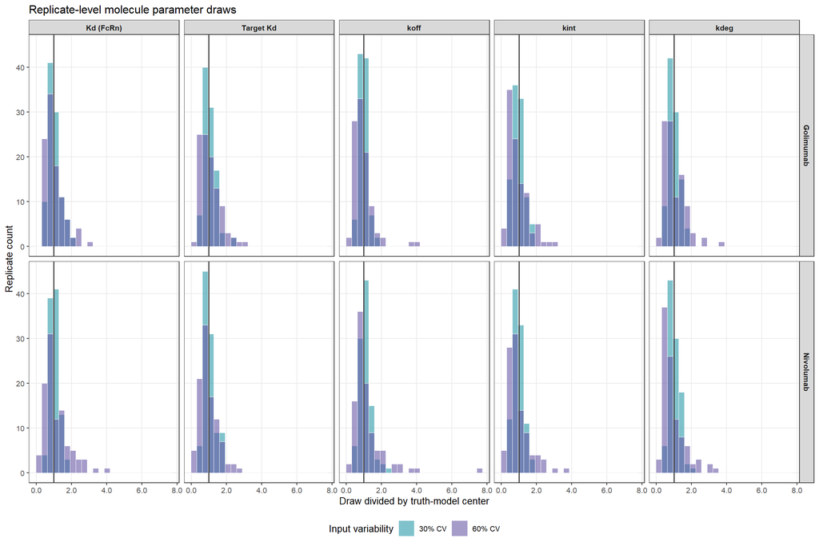

```r
parameter_draw_plot_data <- parameter_draws_long |>
  mutate(
    Ratio_to_truth_center = .data$Parameter_value_display /
      .data$Typical_value_display,
    Variability = factor(
      paste0(100 * .data$Variability_CV, "% CV"),
      levels = paste0(100 * VARIABILITY_CV, "% CV")
    ),
    Parameter = factor(
      .data$Parameter,
      levels = names(PARAMETER_PATHS)
    )
  )

ggplot(
  parameter_draw_plot_data,
  aes(x = .data$Ratio_to_truth_center, fill = .data$Variability)
) +
  geom_histogram(
    bins = 24,
    alpha = 0.58,
    position = "identity",
    color = "white",
    linewidth = 0.2
  ) +
  geom_vline(xintercept = 1, color = "grey25", linewidth = 0.65) +
  facet_grid(rows = vars(.data$Molecule), cols = vars(.data$Parameter)) +
  scale_fill_manual(values = c("30% CV" = "#2596A6", "60% CV" = "#6554A4")) +
  scale_x_continuous(labels = label_number(accuracy = 0.1)) +
  labs(
    x = "Draw divided by truth-model center",
    y = "Replicate count",
    fill = "Input variability",
    title = "Replicate-level molecule parameter draws"
  ) +
  theme_bw(base_size = 10) +
  theme(
    legend.position = "bottom",
    strip.text = element_text(face = "bold"),
    panel.grid.minor = element_blank()
  )
```

# Step 5 Define designs and time grids

The three-dose design uses 0.1, 1, and 10 mg/kg. The fixed sparse schedule is the one used in the prior workflow. Every sparse time is required to be an exact member of the dense analysis grid.

```r
design_manifest <- map_dfr(names(DESIGN_DOSES), function(design) {
  doses <- DESIGN_DOSES[[design]]
  tibble(
    Design = design,
    Dose_groups = length(doses),
    Doses_mg_kg = paste(doses, collapse = ", "),
    N_per_group = ANIMALS_PER_GROUP,
    Total_animals = length(doses) * ANIMALS_PER_GROUP,
    Distinct_within_dose_group = TRUE,
    Reuse_across_dose_groups_allowed = TRUE
  )
}) |>
  arrange(.data$Dose_groups, .data$N_per_group)

if (!setequal(sort(unique(unlist(DESIGN_DOSES))), DOSES_MG_KG)) {
  stop("The candidate designs do not span the required dose grid.")
}
if (any(ANIMALS_PER_GROUP > N_POPULATION_ANIMALS)) {
  stop("A requested dose-group sample exceeds the virtual population.")
}
if (!all(SPARSE_TIME_H %in% DENSE_TIME_H)) {
  stop("At least one sparse sampling time is absent from the dense grid.")
}
if (max(DENSE_TIME_H) != AUC_END_H || max(SPARSE_TIME_H) != AUC_END_H) {
  stop("The dense and sparse grids must both extend through day 28.")
}

time_manifest <- bind_rows(
  tibble(
    Grid = "Dense analysis grid",
    Time_h = DENSE_TIME_H,
    Time_day = DENSE_TIME_H / 24
  ),
  tibble(
    Grid = "Sparse sampling grid",
    Time_h = SPARSE_TIME_H,
    Time_day = SPARSE_TIME_H / 24
  )
)

design_manifest |>
  kable(caption = "Candidate parallel-group monkey study designs")
```

Candidate parallel-group monkey study designs

| Design | Dose_groups | Doses_mg_kg | N_per_group | Total_animals | Distinct_within_dose_group | Reuse_across_dose_groups_allowed |
| --- | --- | --- | --- | --- | --- | --- |
| 2 dose groups | 2 | 1, 10 | 2 | 4 | TRUE | TRUE |
| 2 dose groups | 2 | 1, 10 | 3 | 6 | TRUE | TRUE |
| 2 dose groups | 2 | 1, 10 | 6 | 12 | TRUE | TRUE |
| 3 dose groups | 3 | 0.1, 1, 10 | 2 | 6 | TRUE | TRUE |
| 3 dose groups | 3 | 0.1, 1, 10 | 3 | 9 | TRUE | TRUE |
| 3 dose groups | 3 | 0.1, 1, 10 | 6 | 18 | TRUE | TRUE |
| 5 dose groups | 5 | 0.1, 1, 3, 10, 30 | 2 | 10 | TRUE | TRUE |
| 5 dose groups | 5 | 0.1, 1, 3, 10, 30 | 3 | 15 | TRUE | TRUE |
| 5 dose groups | 5 | 0.1, 1, 3, 10, 30 | 6 | 30 | TRUE | TRUE |

```r
time_manifest |>
  count(.data$Grid, name = "Time_points") |>
  left_join(
    time_manifest |>
      group_by(.data$Grid) |>
      summarise(
        First_time_h = min(.data$Time_h),
        Last_time_h = max(.data$Time_h),
        .groups = "drop"
      ),
    by = "Grid"
  ) |>
  kable(caption = "Dense and sparse analysis grids")
```

Dense and sparse analysis grids

| Grid | Time_points | First_time_h | Last_time_h |
| --- | --- | --- | --- |
| Dense analysis grid | 696 | 0.25 | 672 |
| Sparse sampling grid | 12 | 0.25 | 672 |

# Step 6 Prepare profile and batch manifests

The profile index records every replicate-specific physiology combination that Step 2 must simulate. Each batch contains 10 replicate parameter sets crossed with all 50 monkeys, or 500 profiles per molecule, variability level, and dose.

```r
monkey_ids <- sort(unique(base_population_table$IndividualId))

crossed_profile_index <- expand_grid(
  Molecule = MOLECULES,
  Variability_CV = VARIABILITY_CV,
  Replicate = seq_len(N_REPLICATES),
  PopulationIndividualId = monkey_ids
) |>
  left_join(
    target_population |>
      select(
        .data$Molecule,
        .data$Variability_CV,
        .data$PopulationIndividualId,
        .data$Monkey_index,
        .data$BodyWeight_kg,
        .data$Target_reference_concentration_internal,
        .data$Target_reference_concentration_display,
        .data$Target_display_unit
      ),
    by = c("Molecule", "Variability_CV", "PopulationIndividualId")
  ) |>
  group_by(.data$Molecule, .data$Variability_CV) |>
  arrange(
    .data$Replicate,
    .data$PopulationIndividualId,
    .by_group = TRUE
  ) |>
  mutate(
    BatchId = ceiling(.data$Replicate / N_REPLICATES_PER_BATCH),
    Replicate_within_batch = (.data$Replicate - 1L) %%
      N_REPLICATES_PER_BATCH + 1L,
    SimulationIndividualIdWithinBatch =
      (.data$Replicate_within_batch - 1L) * N_POPULATION_ANIMALS +
      .data$Monkey_index - 1L,
    TruthProfileId = paste(
      .data$Molecule,
      paste0("cv", round(100 * .data$Variability_CV)),
      paste0("rep", sprintf("%03d", .data$Replicate)),
      paste0("monkey", sprintf("%02d", .data$Monkey_index)),
      sep = "_"
    )
  ) |>
  ungroup() |>
  mutate(CrossedPopulationRowId = row_number(), .before = 1)

expected_crossed_rows <- length(MOLECULES) * length(VARIABILITY_CV) *
  N_REPLICATES * N_POPULATION_ANIMALS
if (nrow(crossed_profile_index) != expected_crossed_rows ||
    anyDuplicated(crossed_profile_index$TruthProfileId) > 0L ||
    any(!is.finite(
      crossed_profile_index$Target_reference_concentration_internal
    )) ||
    any(crossed_profile_index$Target_reference_concentration_internal <= 0) ||
    any(!is.finite(crossed_profile_index$BodyWeight_kg)) ||
    any(crossed_profile_index$BodyWeight_kg <= 0)) {
  stop("The crossed profile index is incomplete or contains duplicate IDs.")
}

profile_cell_counts <- crossed_profile_index |>
  count(
    .data$Molecule,
    .data$Variability_CV,
    .data$Replicate,
    name = "Animals"
  )
if (any(profile_cell_counts$Animals != N_POPULATION_ANIMALS)) {
  stop(
    "A replicate does not contain all ",
    N_POPULATION_ANIMALS, " physiological monkeys."
  )
}

simulation_manifest <- expand_grid(
  Molecule = MOLECULES,
  Variability_CV = VARIABILITY_CV,
  Replicate = seq_len(N_REPLICATES),
  Dose_mg_kg = DOSES_MG_KG
) |>
  mutate(
    BatchId = ceiling(.data$Replicate / N_REPLICATES_PER_BATCH),
    Source_scenario = unname(SOURCE_SCENARIOS[.data$Molecule]),
    Expected_animals = N_POPULATION_ANIMALS,
    Expected_dense_time_points_per_animal = length(DENSE_TIME_H),
    Simulation_key = paste(
      .data$Molecule,
      paste0("cv", round(100 * .data$Variability_CV)),
      paste0("rep", sprintf("%03d", .data$Replicate)),
      paste0("dose", gsub("\\.", "p", .data$Dose_mg_kg)),
      sep = "_"
    )
  )

if (nrow(simulation_manifest) !=
    length(MOLECULES) * length(VARIABILITY_CV) *
      N_REPLICATES * length(DOSES_MG_KG) ||
    anyDuplicated(simulation_manifest$Simulation_key) > 0L) {
  stop("The simulation manifest is incomplete or contains duplicate keys.")
}

batch_manifest <- simulation_manifest |>
  group_by(
    .data$Molecule,
    .data$Variability_CV,
    .data$BatchId,
    .data$Dose_mg_kg,
    .data$Source_scenario
  ) |>
  summarise(
    First_replicate = min(.data$Replicate),
    Last_replicate = max(.data$Replicate),
    Replicates = n(),
    Expected_profiles = n() * N_POPULATION_ANIMALS,
    Expected_dense_rows = n() * N_POPULATION_ANIMALS * length(DENSE_TIME_H),
    .groups = "drop"
  ) |>
  mutate(
    Checkpoint_key = paste(
      tolower(.data$Molecule),
      paste0("cv", round(100 * .data$Variability_CV)),
      paste0("dose", gsub("\\.", "p", .data$Dose_mg_kg)),
      paste0("batch", sprintf("%03d", .data$BatchId)),
      sep = "_"
    )
  )

if (any(batch_manifest$Replicates != N_REPLICATES_PER_BATCH) ||
    any(batch_manifest$Expected_profiles !=
        N_REPLICATES_PER_BATCH * N_POPULATION_ANIMALS) ||
    anyDuplicated(batch_manifest$Checkpoint_key) > 0L) {
  stop("The Step 2 batch manifest is invalid.")
}

batch_manifest |>
  count(
    .data$Molecule,
    .data$Variability_CV,
    name = "Dose_batches"
  ) |>
  mutate(`Variability CV (%)` = 100 * .data$Variability_CV) |>
  select(.data$Molecule, `Variability CV (%)`, .data$Dose_batches) |>
  kable(caption = "Planned Step 2 checkpoint batches")
```

Planned Step 2 checkpoint batches

| Molecule | Variability CV (%) | Dose_batches |
| --- | --- | --- |
| Golimumab | 30 | 50 |
| Golimumab | 60 | 50 |
| Nivolumab | 30 | 50 |
| Nivolumab | 60 | 50 |

# Step 7 Save the reviewed Step 1 input record

The saved R object is the sole consolidated input to Step 2. It contains plain tables and settings rather than live simulation objects, so it can be loaded and validated independently in a later R session.

```r
settings <- list(
  workflow_stage = "Step 1: prepare inputs",
  review_required_before_step2 = TRUE,
  molecules = MOLECULES,
  source_scenarios = SOURCE_SCENARIOS,
  source_doses_mg_kg = SOURCE_DOSES_MG_KG,
  model_files = MODEL_FILES,
  doses_mg_kg = DOSES_MG_KG,
  variability_cv = VARIABILITY_CV,
  n_replicates = N_REPLICATES,
  n_population_animals = N_POPULATION_ANIMALS,
  n_replicates_per_batch = N_REPLICATES_PER_BATCH,
  population_name = POPULATION_NAME,
  population_seed_requested = POPULATION_SEED,
  population_seed_used = population_result$seed,
  parameter_draw_seed_base = PARAMETER_DRAW_SEED_BASE,
  target_population_seed_base = TARGET_POPULATION_SEED_BASE,
  nivolumab_fcrn_kd_umol_l = NIVOLUMAB_FCRN_KD_UMOL_L,
  dense_time_h = DENSE_TIME_H,
  sparse_time_h = SPARSE_TIME_H,
  auc_end_h = AUC_END_H,
  animals_per_group = ANIMALS_PER_GROUP,
  design_doses = DESIGN_DOSES,
  parameter_paths = PARAMETER_PATHS,
  target_reference_path = TARGET_REFERENCE_PATH,
  weight_path = WEIGHT_PATH,
  parameter_uncertainty_hierarchy = "shared across monkeys within replicate",
  target_reference_hierarchy = "between-monkey variability only",
  target_reference_cv = VARIABILITY_CV,
  body_weight_variable_across_monkeys = TRUE,
  endogenous_igg_variable_across_monkeys = FALSE,
  fcrn_variable_across_monkeys = FALSE,
  fcrn_population_rationale = paste(
    "The authors concluded that substantial inter-animal FcRn variability",
    "was not expected in the cynomolgus macaques analyzed (Uno et al. 2014;",
    "doi:10.2133/dmpk.DMPK-14-NT-033)."
  ),
  dose_path = DOSE_PATH,
  plasma_output_path = MAB_PLASMA_OUTPUT_PATH,
  calibrated_nivolumab_project_file = CALIBRATED_NIVOLUMAB_PROJECT_FILE,
  uncalibrated_nivolumab_simulated = FALSE
)

step1_record <- list(
  settings = settings,
  software_versions = package_record,
  model_manifest = model_manifest,
  molecular_weights = mw_lookup |>
    select(-.data$Unique_positive_values),
  parameter_centers = parameter_centers,
  parameter_draws_long = parameter_draws_long,
  parameter_draws = parameter_draws,
  parameter_draw_diagnostics = draw_diagnostics,
  base_population = base_population_table,
  population_summary = population_summary,
  target_population = target_population,
  target_population_diagnostics = target_population_diagnostics,
  crossed_profile_index = crossed_profile_index,
  design_manifest = design_manifest,
  time_manifest = time_manifest,
  simulation_manifest = simulation_manifest,
  batch_manifest = batch_manifest
)

saveRDS(step1_record, STEP1_RDS, compress = "xz")

settings_table <- tribble(
  ~Setting, ~Value,
  "Workflow stage", settings$workflow_stage,
  "Review required before Step 2", "TRUE",
  "Truth molecules", paste(MOLECULES, collapse = ", "),
  "Uncalibrated Nivolumab simulations", "None",
  "Nivolumab FcRn-Kd truth center (micromol/L)",
    as.character(NIVOLUMAB_FCRN_KD_UMOL_L),
  "Variability CV (%)", paste(100 * VARIABILITY_CV, collapse = ", "),
  "Replicates per molecule and CV", as.character(N_REPLICATES),
  "Physiological monkeys per replicate", as.character(N_POPULATION_ANIMALS),
  "Replicates per Step 2 batch", as.character(N_REPLICATES_PER_BATCH),
  "Shared uncertain parameters per replicate",
    as.character(length(PARAMETER_PATHS)),
  "Between-monkey variable model inputs",
    "Body weight; target reference concentration",
  "Target reference concentration CV (%)",
    paste(100 * VARIABILITY_CV, collapse = ", "),
  "Endogenous IgG variable across monkeys", "FALSE",
  "FcRn variable across monkeys", "FALSE",
  "Dose grid (mg/kg)", paste(DOSES_MG_KG, collapse = ", "),
  "Dense analysis time points", as.character(length(DENSE_TIME_H)),
  "Sparse sampling time points", as.character(length(SPARSE_TIME_H)),
  "Parameter-draw seed base", as.character(PARAMETER_DRAW_SEED_BASE),
  "Population seed", as.character(population_result$seed),
  "Crossed truth profiles before dose expansion",
    as.character(nrow(crossed_profile_index)),
  "Planned molecule-CV-replicate-dose cells",
    as.character(nrow(simulation_manifest)),
  "Planned checkpoint batches", as.character(nrow(batch_manifest))
)
artifact_paths <- c(
  STEP1_RDS,
  BASE_POPULATION_FILE,
  TARGET_POPULATION_FILE,
  PARAMETER_DRAW_FILE
)
assert_files_exist(artifact_paths, "Generated Step 1 artifact")

artifact_manifest <- tibble(
  Artifact = basename(artifact_paths),
  Path = normalizePath(artifact_paths, winslash = "/", mustWork = TRUE),
  Bytes = file.info(artifact_paths)$size,
  MD5 = unname(tools::md5sum(artifact_paths))
)
loaded_record <- readRDS(STEP1_RDS)
if (!identical(loaded_record$parameter_draws_long, parameter_draws_long) ||
    !identical(loaded_record$base_population, base_population_table) ||
    !identical(loaded_record$target_population, target_population) ||
    !identical(loaded_record$batch_manifest, batch_manifest)) {
  stop("The saved Step 1 R object failed its round-trip validation.")
}

settings_table |>
  kable(caption = "Step 1 settings for review")
```

Step 1 settings for review

| Setting | Value |
| --- | --- |
| Workflow stage | Step 1: prepare inputs |
| Review required before Step 2 | TRUE |
| Truth molecules | Golimumab, Nivolumab |
| Uncalibrated Nivolumab simulations | None |
| Nivolumab FcRn-Kd truth center (micromol/L) | 0.39 |
| Variability CV (%) | 30, 60 |
| Replicates per molecule and CV | 100 |
| Physiological monkeys per replicate | 50 |
| Replicates per Step 2 batch | 10 |
| Shared uncertain parameters per replicate | 5 |
| Between-monkey variable model inputs | Body weight; target reference concentration |
| Target reference concentration CV (%) | 30, 60 |
| Endogenous IgG variable across monkeys | FALSE |
| FcRn variable across monkeys | FALSE |
| Dose grid (mg/kg) | 0.1, 1, 3, 10, 30 |
| Dense analysis time points | 696 |
| Sparse sampling time points | 12 |
| Parameter-draw seed base | 20260919 |
| Population seed | 20260919 |
| Crossed truth profiles before dose expansion | 20000 |
| Planned molecule-CV-replicate-dose cells | 2000 |
| Planned checkpoint batches | 200 |

```r
artifact_manifest |>
  select(.data$Artifact, .data$Bytes, .data$MD5) |>
  kable(caption = "Step 1 artifacts and checksums")
```

Step 1 artifacts and checksums

| Artifact | Bytes | MD5 |
| --- | --- | --- |
| study_design_step1_inputs.rds | 33044 | b5cac00695e6599a49ae135dd3f5124b |
| study_design_base_monkey_population.csv | 2130 | 33517fa4fe6b145ee0ba08ee76ade32f |
| study_design_target_population.csv | 22352 | 61afa6d0dec52bbb7fa2a0de013b265b |
| study_design_parameter_draws.csv | 201132 | 096e7bd11df0c18d1c96f4c6871e4d3f |

# Review checklist

Before authorizing Step 2, confirm that:

1. only the nominal Golimumab truth and calibrated Nivolumab truth are listed;
2. the Nivolumab FcRn-Kd truth center is 0.39 micromol/L;
3. each molecule has 100 replicates at 30% CV and 100 at 60% CV;
4. every replicate has all five positive shared uncertain inputs;
5. the physiological population contains 50 unique monkeys, with body weight and target reference concentration as the only between-monkey inputs;
6. the three-dose design is 0.1, 1, and 10 mg/kg;
7. the sparse grid contains the 12 agreed times through day 28;
8. each batch contains 10 replicate draws and 500 profiles before dose expansion;
9. no concentration-time simulation has been run by this script; and
10. the saved tables and consolidated R object have the expected checksums.